# Lab8 Gene Expression

#### Q4) Now both run hierarchical clustering and plot the results in two dimensions (on samples and genes). Plot a heatmap with the genes on the y-axis and samples on the x-axis. Once again, make sure that the sample and genes labels are present. Title the plot.

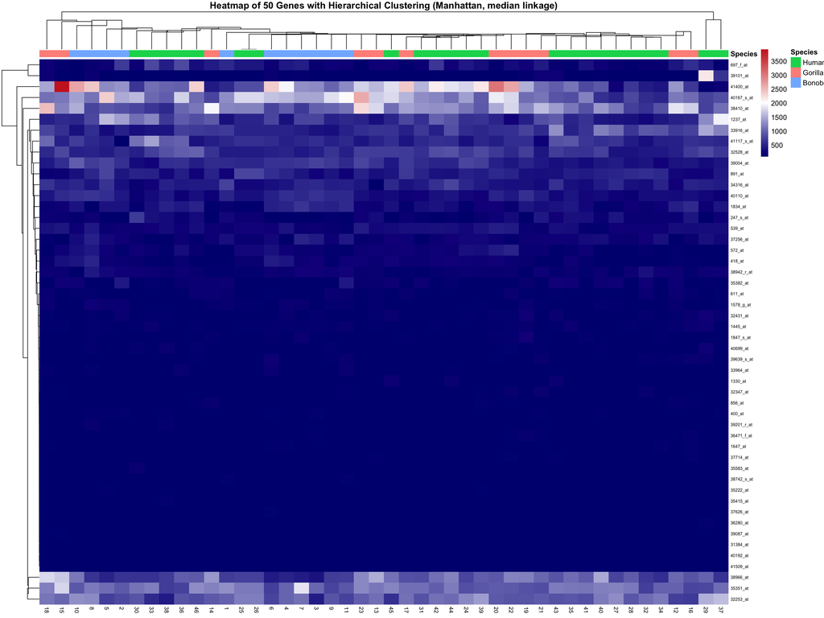

```r
# Q4: Hierarchical clustering on samples & genes; heatmap on the 50 selected genes
stopifnot(exists("subset_data"))
mat <- as.matrix(subset_data)

# Build annotation for species (reuse from Q3)
if (exists("species") && length(species) == ncol(mat)) {
  ann_col <- data.frame(Species = species)
  rownames(ann_col) <- colnames(mat)
} else {
  pd <- Biobase::pData(fibroEset)
  samp <- colnames(mat)
  is_hgb_col <- function(v){
    u <- unique(na.omit(trimws(toupper(as.character(v)))))
    length(u) > 0 && all(u %in% c("H","G","B"))
  }
  hgb_col <- if (ncol(pd)) names(pd)[vapply(pd, is_hgb_col, logical(1))] else character(0)
  if (length(hgb_col) > 0) {
    code <- toupper(trimws(as.character(pd[[hgb_col[1]]])))
  } else {
    tok <- function(L) grepl(paste0("(^|[^A-Za-z])", L, "([^A-Za-z]|$)"), samp, ignore.case = TRUE)
    code <- ifelse(tok("H"), "H", ifelse(tok("G"), "G", ifelse(tok("B"), "B", NA_character_)))
  }
  map_hgb <- c(H="Human", G="Gorilla", B="Bonobo")
  species <- factor(map_hgb[code], levels = c("Human","Gorilla","Bonobo"))
  ann_col <- data.frame(Species = species)
  rownames(ann_col) <- colnames(mat)
}

# Color palette
cols <- colorRampPalette(c("navy", "white", "firebrick3"))(255)

# Create the heatmap and store as object
heat <- pheatmap::pheatmap(
  mat,
  color = cols,
  clustering_distance_rows = "manhattan",
  clustering_distance_cols = "manhattan",
  clustering_method = "median",
  show_rownames = TRUE,
  show_colnames = TRUE,
  annotation_col = ann_col,
  main = "Heatmap of 50 Genes with Hierarchical Clustering (Manhattan, median linkage)",
  fontsize_row = 6,
  fontsize_col = 8,
  border_color = NA
)
```

#### Q5) Calculate PCA on the samples and retain the first two components vectors (eigenfunctions). Calculate k-means clustering on these first two components with k=3.

```r
# Q5: PCA on samples and k-means clustering (k = 3)

# Ensure the subset data exists
stopifnot(exists("subset_data"))
mat <- as.matrix(subset_data)

# Transpose so samples are rows and genes are columns
sample_matrix <- t(mat)

# Run PCA
pca_result <- prcomp(sample_matrix, center = TRUE, scale. = TRUE)

# Extract the first two principal components
pca_df <- as.data.frame(pca_result$x[, 1:2])
colnames(pca_df) <- c("PC1", "PC2")

# Run k-means clustering on the first two components
set.seed(42)
kmeans_result <- kmeans(pca_df, centers = 3, nstart = 25)

# Add cluster assignments to the PCA data
pca_df$Cluster <- as.factor(kmeans_result$cluster)

# Optional: Add true species labels (for later comparison in Q6)
if (exists("species")) {
  pca_df$Species <- species
} else {
  pca_df$Species <- NA
}

# View PCA variance explained
explained_var <- summary(pca_result)$importance[2, 1:2]
cat("Proportion of variance explained by PC1 and PC2:\n")
```

```
Proportion of variance explained by PC1 and PC2:
```

```r
print(round(explained_var * 100, 2))
```

```
  PC1   PC2
12.17  9.46
```

```r
# Preview the PCA + cluster assignments
head(pca_df)
```

```
        PC1        PC2 Cluster Species
1 0.9856861 -0.7683405       2  Bonobo
2 1.1637193 -1.9626367       2  Bonobo
3 2.0530597 -2.1629863       2  Bonobo
4 1.6747815  0.3488903       2  Bonobo
5 2.6490763 -1.3391857       2  Bonobo
6 3.1475741 -3.1664539       2  Bonobo
```

**Interpretation:** The PCA reduced the 50-gene expression data to two principal components that together explain about 21.6% of the total variance (PC1 = 12.17%, PC2 = 9.46%). These two components capture the largest sources of variation across samples, compressing complex gene-expression patterns into a 2D space suitable for clustering. The k-means algorithm with k = 3 was then applied to the first two principal components to identify three major sample groupings, corresponding to the expected number of species. The previewed assignments show that the Bonobo samples primarily fall into the same cluster (Cluster 2), suggesting the PCA and k-means combination successfully separated at least one species group. Although the total variance explained by PC1 and PC2 is modest, meaning that much of the gene expression variation lies in higher components, the low-dimensional projection still captures biologically meaningful structure consistent with species differences.